# Truth Behind the Scenes

Welcome to challenge the world!

## Who

- cchuang,

and

- You, you, and you.

## How

- Lectures
- Labs
- Home Work
- on-line Review Quizzes
- Group Project

# Lecture Resources

- [CGU 2015-1](http://120.126.22.84:8888) Repository of This semester
  - [CGU 2015-1 Nbviewer](http://120.126.22.84:5000/localfile/math/2015-1/index.ipynb) Nbviewer Service
- Historic lectures
  - [CGU 2014-1](http://120.126.22.84:8888/notebooks/math-2014/index.ipynb)
  - [CGU 2014-2](http://120.126.22.84:8888/notebooks/math-2014/2014-2/2015-3-11.ipynb)
- [CGU] http://diffusion.cgu.edu.tw/2015/math/2015-1
- [github] https://github.com/cchuang2009

# Reference Books

## Art:

- **B. Artalay**: Math and the Mona Lisa: The art and Science of Leonardo Da Vinci
- **Jan Steward**, The New Mathematics of the Living World,

## Science and Computer:

- **Hans Petter Langtangen**: A Primer on Scientific Programming with Python, 2012, Springer Publ.
- **Robert K. Adair**: The Physics of Baseball 3rd Ed. 2002, Perennial.
- **Ben O'Donnell, et. al.**: Computing the Sir Model: Fractal dimension leads to vaccination strategies.
- **Allen Hunt**: A new Conceptual Model for Forest Fires Based on Percolation Theory, Complexity, pp 12-17, Vol 13, N.3 2008
- **Cyrille Rossant**, Learning IPython for Interactive Computing and Data Visualization, Packt Publishing, 2013.

## Advanced References

- **Hans Petter Langtangen**: Python Scripting for Computational Science, 3rd Ed. 2007, Springer Publ.
- **Angela B. Shiflet and George W. Shiflet** : Introduction to Computational Science, 2014

## Course Syllabus

Mathematics is an important field in scientific study. Nowadays, It becomes more vivid than ever due to the progress in innovatory science and introduction of modern technology, such as computers and internet. Such kind of technology also bring the new phenomena which human being always neglect or have not observed in the history.

This course will be an introduction to the mathematical modeling of systems in nature and around our life.

Observations on the specific topics dicussed in the lecture would be progressed by theoretical analysis and computer simulation simulataneously with which we could explore truth and the secret behind the problems deeply more than ever (hope so)..

Though the computer skills is not the necessary in this course, pedagogy always includes an introduction to mathematical model building, exploring simple hands-on and simulated experiments using computers mathematical software.

The models introduced in this course includes:

- Epidemic Model: Fractal dimension leads to vaccination strategies:
- Baseball: The reason way the slider of Chien-Ming Wang is very hard to be hit.
- Random : How to estimate the true value of pi only by tossing a stick on ruled paper?
- Percolation: Why does the forest fire damage human beings?
- Weather prediction: The path of Typhoon affected by Coriolis Force.

Mostly, numerical analysis will be taken to explore reality behind the selected models instead of induced by pure mathematical theory while it is too complicate to lay-in. Students will have the opportunity to develop and analyze mathematical models of real world both in continuous and discrete processes.

## 中文課程簡介

自從上世紀以來，數學在定性研究上有許多突破性的發展，再加上計算機軟硬體的快速進展，這就是常被用來探討生活中許多現象產生的原因。這一門課程，我們將結合兩者的長處，藉由探討實際的例子，介紹各種可以應用到學生本業的實用工具。課程涵蓋的例子，主要包含：

- 花朵的模型，為什麼植物知道 Fibonacci 的級數理論?
- 傳染病模型: 2003 SARS 為什麼像森林的火災，來勢洶洶重創台灣, 港, 大陸?
- 為什麼王建民的 Sinker 那麼厲害?
- 花豹的斑紋，蛇的斑紋，為什麼跟心臟電壓有關係?

這些例子所包含的數學工具，包含甚廣，從數論，微分方程，最佳化等等分析理論到圖學，隨機理論皆涵蓋，也是醫學、工程及管理領域，常見的工具，課程的另一目的，即藉由探討實際問題中，學習如何學以致用的精諦。

[Topics]

- 1. Introduction
- Set your own environment ...

## Requirements of Python and its Modules

- Python - 2.7.x or 3.4.x
- SciPy/NumPy, Pandas, Sympy;
- Matplotlib, seaborn, Bokeh;
- IPython ( >2.+), ipywidgets, JSAnimation, ipy_table,

**[Optional]**

- ivisual (>0.1.90),

```python
%install_ext https://raw.githubusercontent.com/rasbt/watermark/master/watermark.py
```

```
Installed watermark.py. To use it, type:
  %load_ext watermark
```

```python
%load_ext watermark

%watermark -p IPython,sympy,scipy,numpy,matplotlib,pandas,seaborn,JSAnimation,scikit_image,Bokeh,nbviewer
```

```
IPython 4.1.0.dev0
sympy 0.7.6
scipy 0.16.0
numpy 1.9.2
matplotlib 1.4.3
pandas 0.16.2
seaborn 0.6.0
JSAnimation 0.1
scikit_image 0.11.3
Bokeh 0.9.2
nbviewer 0.2.0
```

## Installation Howto

You should choose one of the following solutions to run your labs:

- install **anaconda** ( Linux, Mac, Windows);
- register an account at **SageCloud** (Any Devices);
- install platform on USB stick (>8G bytes; Kingston and Sony recommended) to play on your own computer or laptop

## Grading

- Lecture Attendance: 20%
- Computer Practices: 20%
- Conceptual Quizzes: 30%
- Group project AND Term Report: 30%

**Final Project**

- Your chance to show off what you learned
- Hand-ins:
  - written paper (<= 6 pages) • screencast
  - poster
  - optional: webpage

## Office hour

- Tuesday, 12:00 P.M. ~ 13:00 P.M.
- Wednesday, 12:00 P.M. ~ 13:00 P.M.

## Survey

You have to follow the link to login the lecture:

- [LoginIn](http://120.126.22.84/CGU)

# Marilvn vos Savant

```
         To acquire knowledge, one must study;
         but to acquire wisdom one must observe.
```

```python
# Execute this cell to load the notebook's style sheet, then ignore it
from IPython.core.display import HTML
css_file = 'styles/custom.css'
HTML(open(css_file, "r").read())
```

```python
from IPython.display import YouTubeVideo,HTML,Image
# <!-- collapse=False -->
HtmlCode="""
<div class="stage" style="width: 240px; height: 160px;">
<div class="spinner">
<img style="-webkit-transform: rotateY(0deg) translateZ(165px); -moz-transform: rotateY(0deg) translateZ(165px); -ms-transform: rotateY(0deg) translateZ(165px); padding: 0px 20px;" src="http://120.126.22.84:8888/files/math/2015-1/imgs/ms.gif" alt="" height="200px" width="200px">
<img style="-webkit-transform: rotateY(72deg) translateZ(165px); -moz-transform: rotateY(72deg) translateZ(165px); -ms-transform: rotateY(72deg) translateZ(165px); padding: 0px 13.5px;" src="http://120.126.22.84:8888/files/math/2015-1/imgs/fft.gif" alt="" height="200px" width="200px">
<img style="-webkit-transform: rotateY(144deg) translateZ(165px); -moz-transform: rotateY(144deg) translateZ(165px); -ms-transform: rotateY(144deg) translateZ(165px); padding: 0px 0px;" src="http://120.126.22.84:8888/files/math/2015-1/imgs/elephant.gif" alt="" height="200px" width="200px">
<img style="-webkit-transform: rotateY(216deg) translateZ(165px); -moz-transform: rotateY(216deg) translateZ(165px); -ms-transform: rotateY(216deg) translateZ(165px); padding: 0px 13.5px;" src="http://120.126.22.84:8888/files/math/2015-1/imgs/traj.png" alt="" height="200px" width="200px">
<img style="-webkit-transform: rotateY(288deg) translateZ(165px); -moz-transform: rotateY(288deg) translateZ(165px); -ms-transform: rotateY(288deg) translateZ(165px); padding: 0px 1px;" src="http://120.126.22.84:8888/files/math/2015-1/imgs/Monalisa.png" alt="" height="300px" width="200px">
</div>
</div>
<p><p><p>
"""
HTML(HtmlCode)
```

[figure not shown]

```python
#  Dean Martin - Mona Lisa
YouTubeVideo('iRe6AZlswmw')
```

[video not shown]

## What The Golden ratio is

$$\gamma \sim1.6180339887498949 \quad\left(= \frac{1+\sqrt 5}{2}\right)$$

# Secrect in Art

## Mona Lisa

|  | **What is the relation between $\mathbf{\gamma}$ and this materpiece?** |
| --- | --- |

```python
%matplotlib inline

import matplotlib.pyplot as plt
from skimage.segmentation import slic,mark_boundaries
from skimage.data import lena
from skimage.util import img_as_float
import skimage.io as io
```

```
image shape: (599, 402, 3)
```

[figure not shown]

```python
Monalisa = io.imread('imgs/Monalisa.png')
print('image shape:', Monalisa.shape)
io.imshow(Monalisa)
#io.show()
```

[output not shown]

[figure not shown]

```python
from skimage import filter
Monalisa_zoom = Monalisa[55:320, 120:280]
#Monalisa_filter=filter.denoise_tv_chambolle(Monalisa_zoom, weight=0.1)
io.imshow(Monalisa_zoom)
```

```python
# Estimate the ratio of height/width of beautiful face we catched
RR=(320-55)/(280.-120)
Error=(RR-1.618)/1.618
print(RR)
print('error = %s' %Error)
```

```
1.65625
error = 0.0236402966625
```

## Sunflower

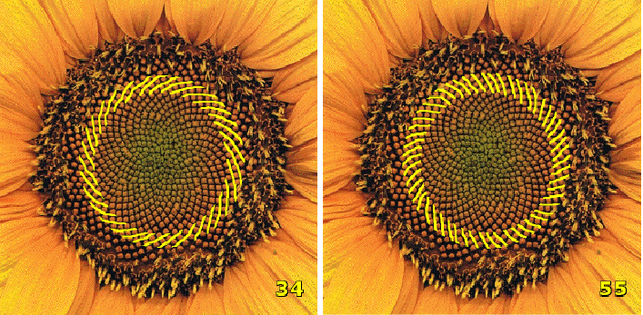

```python
from IPython.display import Image
Image("imgs/sunflower121.png")
```

```python
55/34.
```

```
1.6176470588235294
```

It is very close to $\gamma$!

## Fibonicci Sequence

The term follows the following rules:

\begin{eqnarray} f_0,f_1 &= &1, \\ f_2&=&f_0+f_1=2,\\ \vdots\\ f_{n+1}&=&f_n+f_{n-1}, n=1,2,3, \end{eqnarray}

This means:
$$\{f_n\}^{\infty}_0 = 1,1,2,3,5,8,13,21,34,55,89,\cdots$$

## Limit of Rotio of Sequences

### Conclusion

$$\mathbf{\lim\limits_{n\to\infty}\frac{f_{n+1}}{f_n}=\frac{1+\sqrt5}{2}\sim1.6180339887498949}$$

**Just the Golden Ratio!**

## Unit In Radical Degree

It is congrant to $137.52^\circ$

```python
360-360*1.618%360
```

## Animation Show

One Pictire is better than one thousand words, and one animation is better than one thousand pictures.

```python
from JSAnimation.IPython_display import display_animation
import matplotlib.pyplot as plt
from matplotlib import animation
import numpy as np
```

```python
fig = plt.figure(figsize=(6,6))

ax = plt.axes(xlim=(-2, 2), ylim=(-2, 2),aspect="equal");
#ar=137.52
ar=139.5
r0=0.1
r=0.03
deg2rad=np.pi/180.
c = ax.add_patch(plt.Circle((0, 0), radius=r0,color="#ff0000",facecolor='none'))
Nframes = 50
def animate(nframe):
    f = nframe
    rm=r0+np.sqrt(f)*0.014
    ang=f*ar*deg2rad
    gam= 0.5*(1.4-f/float(Nframes))
    c = ax.add_patch(plt.Circle((r*f*np.cos(ang), r*f*np.sin(ang)), radius=rm, color="red",facecolor='none',alpha=gam))
    return c
```

```python
anim = animation.FuncAnimation(fig, animate, frames=Nframes, interval=100)
display_animation(anim, default_mode='once')
```

[figure not shown]

Once Loop Reflect

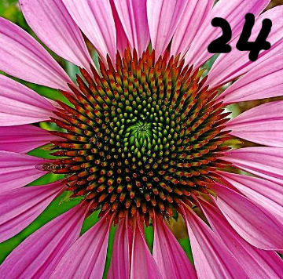

```python
Image("imgs/Chrysanthemum.png")
```

## Review Exercise

Dive out the concern golden ratio hidden in the above picture.

# Sound

## Recall of Nature

Befitting the largest mammal on earth, the call of an adult blue whale is loud (amptitude) and low (frequencies). The sound carries farther than any other animal sound, and can be detected over a thousand miles away. The call has a distinct pattern, which usually precedes a series of B *moans*.

## Pattern of Tones

The B call is simpler and easier to analyze, which consists of:

- a fundamental frequency around *16-17* hertz
- and a series of harmonics(multiples) of the fundamental frequency.

Here, the amplitude of the call is modulated to produce a loud moan followed by weaker moan.

## Simulation of Sound

- The signal itself is treated as a sum of harmonics

$$\sum_{n=0}^\infty\sin(2 \pi n f_0 t)$$

- The envelope of the signal is treated as a decaying sine wave of the form $$A_0 e^{-B}\sin(2 \pi f_m t)$$ where the amplitude $A_0$, the decay rate $B$, and the modulating frequency $f_m$.
- Because blue whale calls are so low, they are barely audible to humans. The time scale in the data being modeled is compressed by a factor of 10 to raise the pitch and make it more clearly audible. The model works with the same $\times 10$ audible frequencies.

```python
%matplotlib inline

import numpy as np
from numpy import sin,pi,exp
import matplotlib.pylab as plt
from IPython.display import Audio, Image
```

```python
fs = 4000;
xmax=1.5
t = np.linspace(0,xmax,fs);
# Set the fundamental frequency of the call.
f0 = 175;
# Create the harmonics.
y0 = sin(2*pi*f0*t) + sin(2*pi*2*f0*t) + sin(2*pi*3*f0*t);
# Set the additional parameters in the model.
A0 = 2; #Initial amplitude.
B = 1.5; # Amplitude decay rate.
fm = 0.65; # Frequency of the modulating envelope.
# Create the envelope

A = A0*exp(-B*t)*sin(2*pi*fm*t);
```

[interactive chart not shown]

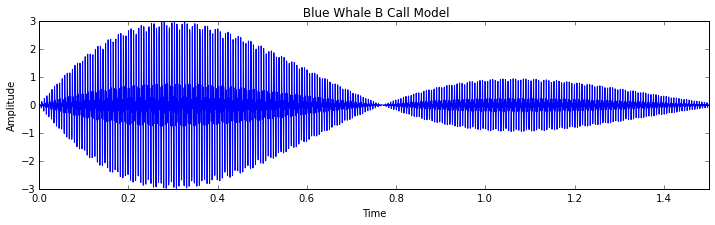

```python
call = A*y0;
# Plot the model call and listen to it.
plt.figure(figsize=(12,3))
plt.plot(t,call)
plt.xlabel('Time');plt.ylabel('Amplitude');plt.xlim(0,xmax)
plt.title(' Blue Whale B Call Model')

Audio(call.astype(np.int16),rate=fs)
```

# Big Data

How to dig out useful information from data polls.

```python
import pandas as pd
data = pd.read_csv('data/POIAsia.csv', nrows=5)
data.columns
```

```
Index([u'"osmid"', u'name', u'amenity', u'emergency', u'geological',
       u'historic', u'leisure', u'man_made', u'office', u'shop', u'sport',
       u'tourism', u'craft', u'Longitude', u'Latitude'],
      dtype='object')
```

```python
from dask import dataframe as dd
columns = ["name", "amenity", "Longitude", "Latitude"]
data = dd.read_csv('data/POIAsia.csv', usecols=columns)
data.columns
```

```
(u'name', u'amenity', u'Longitude', u'Latitude')
```

```python
# get rid of incompleted data (with null value)
with_name = data[data.name.notnull()]
with_amenity = data[data.amenity.notnull()]
```

```python
is_starbucks = with_name.name.str.contains('[Ss]tarbucks')

starbucks = with_name[is_starbucks]
```

```python
is_KFC= with_name.name.str.contains('[Kk][Ff][Cc]')

KFC = with_name[is_KFC]
dd.compute(KFC.name.count())
```

```
(958,)
```

```python
is_mcdonald = with_name.name.str.contains('[Mm]c[Dd]onald')
mcdonald = with_name[is_mcdonald]

dd.compute(mcdonald.name.count())
```

```
(1107,)
```

```python
locs = dd.compute(starbucks.Longitude,
                  starbucks.Latitude,
                  KFC.Longitude,
                  KFC.Latitude,
                  mcdonald.Longitude,
                  mcdonald.Latitude)

# extract arrays of values from the series:
lon_s, lat_s, lon_k, lat_k, lon_m, lat_m = [loc.values for loc in locs]
```

```python
%matplotlib inline
import matplotlib.pyplot as plt
from mpl_toolkits.basemap import Basemap

def draw_Taiwan():
    """initialize a basemap centered on the Taiwan"""
    return Basemap(projection='lcc', resolution='l',
                   llcrnrlon=120, urcrnrlon=122,
                   llcrnrlat=20, urcrnrlat=26, lat_1=23,lon_0=122,area_thresh=1000)
```

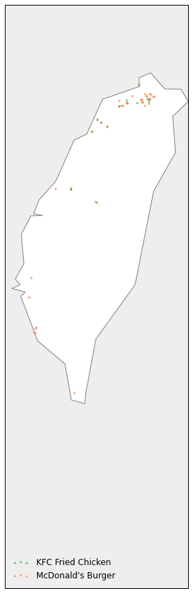

```python
fig, ax = plt.subplots(figsize=(15, 15))

m = draw_Taiwan()
# Draw map background
m.fillcontinents(color='white', lake_color='#eeeeee')
m.drawstates(color='lightgray')
m.drawcoastlines(color='gray')
m.drawcountries(color='lightgray')
m.drawmapboundary(fill_color='#eeeeee')

# Plot the values in Starbucks Green and Dunkin Donuts Orange
style = dict(s=5, marker='o', alpha=0.5, zorder=2)
#m.scatter(lon_s, lat_s, latlon=True,
#          label="Starbucks", color='#00592D', **style)
m.scatter(lon_k, lat_k, latlon=True,
          label="KFC Fried Chicken", color='#22AA36', **style)
m.scatter(lon_m, lat_m, latlon=True,
          label="McDonald's Burger", color='#FC772A', **style)

plt.legend(loc='lower left', frameon=False);
```

```python
is_fastfood = with_amenity.amenity.str.contains('fast_food')
fastfood = with_amenity[is_fastfood]
fastfood.name.value_counts().head(12)
```

```
マクドナルド           919
McDonald's       778
KFC              709
松屋               489
Jollibee         411
すき家              397
モスバーガー           349
吉野家              335
ケンタッキーフライドチキン    263
Subway           227
CoCo壱番屋          173
Chowking         159
dtype: int64
```

```python
%%bash

ipython nbconvert index.ipynb
```

```
[NbConvertApp] Converting notebook index.ipynb to html
[NbConvertApp] Writing 2528540 bytes to index.html
```

## Appendix

Without doubt, HTML5 strengtens ability and functionalities on IPython notebook user interface more than other interfaces. The IPython notebook functionality (i.e. what you do with the Browser) can be extended using Javascript extensions.

Here the examples to show how to install the monitoring extension about installed packages and display what kind of extensions were installed:

```python
#%install_ext http://raw.github.com/jrjohansson/version_information/master/version_information.py
%load_ext version_information
%reload_ext version_information

%version_information numpy, scipy, matplotlib, JSAnimation
```

[output not shown]

| Software | Version |
| --- | --- |
| Python | 3.4.3 64bit [GCC 4.2.1 (Apple Inc. build 5577)] |
| IPython | 3.2.0 |
| OS | Darwin 14.5.0 x86_64 i386 64bit |
| numpy | 1.9.2 |
| scipy | 0.16.0 |
| matplotlib | 1.4.3 |
| JSAnimation | 0.1 |
| Tue Aug 25 09:34:10 2015 CST |  |

```python
from IPython.html.services.config import ConfigManager
from IPython.display import HTML
ip = get_ipython()
cm = ConfigManager(parent=ip, profile_dir=ip.profile_dir.location)
extensions =cm.get('notebook')
table = ""
for ext in extensions['load_extensions']:
    table += "<tr><td>%s</td>\n" % (ext)

top = """
<table border="1">
  <tr>
    <th>Extension name</th>
  </tr>
"""
bottom = """
</table>
"""
HTML(top + table + bottom)
```

| Extension name |
| --- |
| nbgrader/create_assignment |
| livereveal/main |